# Introduction to Statistics

Bennett Kleinberg

Week 9

## Week 9

- Part 1: Effect sizes
- Part 2: Confidence intervals

Part 1: Effect sizes

## Recap

1. Define hypotheses (always: null + alternative)
2. Determine $\alpha$
3. (Find critical values)
4. Calculate $t$ (or: $z$)
5. Make a decision

## Four cases

- the z-test
- the one-sample t-test
- the independent t-test
- the dependent t-test

## Commonalities

- all tests have the same structure
- $test\ statistic = \frac{difference\ in\ means}{standard\ error}$
- hence: smaller $SE$ = larger test statistic

## t as a function of n

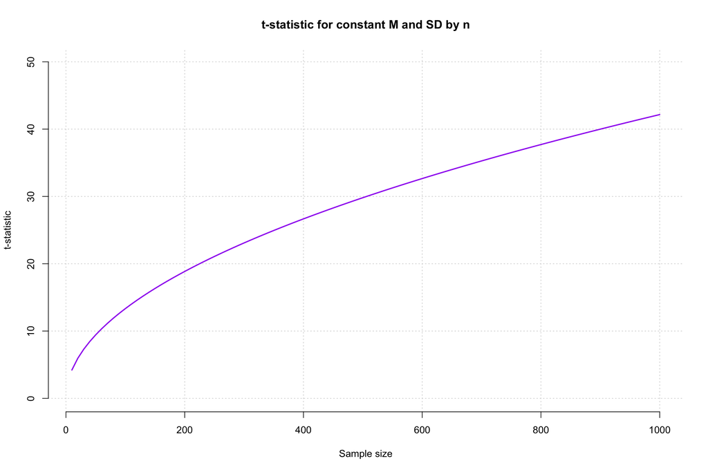

## Remember

(one-sample case)

$t = \frac{M-\mu}{s_M}$

with $s_M = \frac{s}{\sqrt{n}}$

Again: with bigger $n$, the estimated standard error $s_M$ decreases…

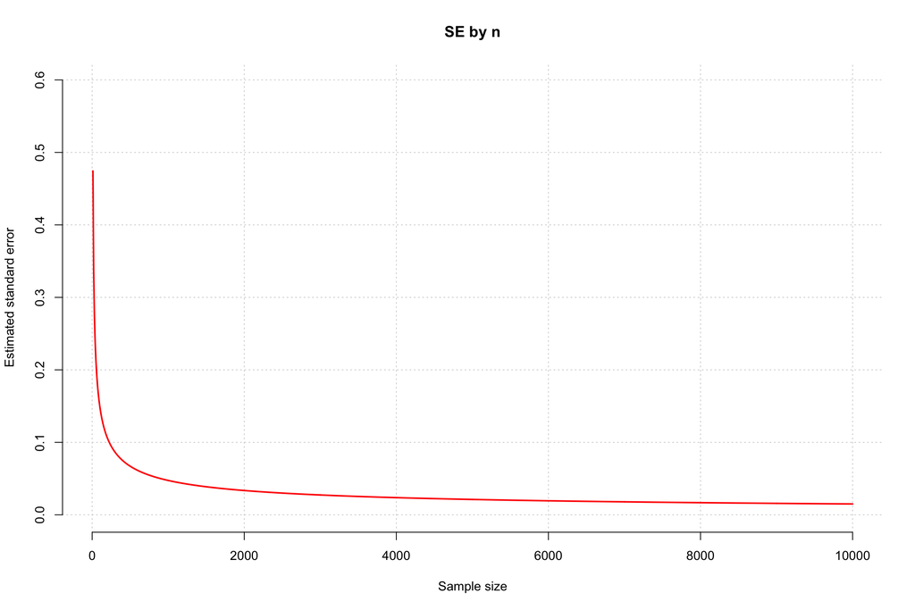

## The problem

- a test statistic from hypothesis testing is very limited
- … because it is a function of the sample size $n$

Thus: a t-value does not tell us much about the **magnitude of the effect**.

*Based on $t$, we cannot say anything about how “meaningful” a significant difference is.*

## n affects significance

[output not shown]

## Another issue

Suppose we have two one-sample t-tests:

- Study 1: people reported higher happiness scores ($M=5.46$, $SD=1.34$) than a neutral midpoint, $t(99) = 3.43, p < .01$
- Study 2: people reported higher happiness scores ($M=5.46$, $SD=1.34$) than a neutral midpoint, $t(999) = 10.86, p < .01$

*How can we possibly compare these two studies?*

## Needed:

We need a *metric* to tell us about the effect independent of *sample size*.

This metric would provide us the absolute magnitude of an effect (corrected for sample size).

We call these metrics **effect sizes**

## Solution

Effect sizes help us express the actual effect *indepedent* of the sample size.

For mean comparison tests (z-tests and t-tests), we use the effect size **Cohen’s d** (there are dozens of different effect sizes!).

We now do this step-by-step for our four tests.

- the z-test
- the one-sample t-test
- the independent t-test
- the dependent t-test

## Effect size for the z-test

Scenario: for $\mu = 100$ and $\sigma =15$ of a normally distributed IQ score, we want to know whether observing $M=110$ is statistically significant for $n=30$ [$n=300$].

We know that $z=\frac{m-\mu}{\sigma_M}$ and $\sigma_M = \frac{\sigma}{\sqrt{n}}$

## Calculating z

For $n=30$: $\sigma_M = \frac{15}{\sqrt{30}} = 2.74$, so $z=\frac{110-100}{2.74} = 3.65$

For $n=300$: $\sigma_M = \frac{15}{\sqrt{300}} = 0.87$, so $z=\frac{110-100}{0.87} = 11.49$

Both are significantly larger than 100 ($p<.01$).

## Calculating the effect size

But now what?

We know that the second z-score was larger because of the sample size. Cohen’s d helps us:

$d=\frac{mean\ difference}{standard\ deviation} = \frac{M-\mu}{\sigma}$

We thus measure the effect in terms of *standard deviations moved*.

$d=\frac{110-100}{15} = \frac{10}{15} = 0.67$

## Interpreting $d$

- $d=0.20$ –> small effect
- $d=0.50$ –> medium effect
- $d=0.80$ –> large effect

(See page 253)

## Effect size for the t-test (1)

*The one-sample t-test*

Scenario: is a reported happiness scores ($M=5.46$, $SD=1.34$) higher than a neutral midpoint of 5 for $n=100$ [$n=1000$]?

We know that $t = \frac{M-\mu}{s_M}$ with $s_M = \frac{s}{\sqrt{n}}$.

## Calculating t

- $n=100$: $s_M = \frac{1.34}{\sqrt{100}} = 0.13$ so $t = \frac{5.46-5.00}{0.13} = 3.53$
- $n=1000$: $s_M = \frac{1.34}{\sqrt{1000}} = 0.04$ so $t = \frac{5.46-5.00}{0.04} = 11.50$

Both are significantly larger than 5 ($p < .01$).

## Calculating the effect size

Cohen’s d here has the same logic:

$d=\frac{M - \mu}{s}$ (note: following the t-test logic, we are estimating population parameters)

So: $estimated\ d = \frac{5.46-5.00}{1.34} = 0.34$

i.e. we are only talking about a small-to-medium effect (in both cases!)

## Effect size for the t-test (2)

*The independent t-test*

Scenario: did poker players who mediated before they played ($M=4500$, $SD=780$) earn more prize money than players who did not meditate ($M=3500$, $SD=580$) ($n_1 = n_2 = 25$) [($n_1 = n_2 = 250$)]?

We know that $t = \frac{(M_1-M_2)-(\mu_1-\mu_2)}{s_{(M_1-M_2)}}$ with $s_{M_1-M_2} = \sqrt{{\frac{s_p^2}{n_1}+\frac{s_p^2}{n_2}}}$ with $s_p^2 = \frac{df_1*s^2_1+df_2*s^2_2}{df_1+df_2}$ and $df=n_1+n_2-2$

## Calculating t

For $n_1 = n_2 =25$:

$s_p^2 = \frac{24*780^2+24*580^2}{24+24}=472400$, so that

$s_{M_1-M_2} = \sqrt{{\frac{472400}{25}+\frac{472400}{25}}}=194.40$

$t = \frac{(4500-3500)}{194.40} = 5.14$

## Calculating t

For $n_1 = n_2 =250$:

$s_p^2 = 472400$, so that

$s_{M_1-M_2} = \sqrt{{\frac{472400}{250}+\frac{472400}{250}}}=61.48$

$t = \frac{(4500-3500)}{61.48} = 16.27$

In both cases: the group that meditated earned significantly more prize money than the control group ($p < .01$).

## Calculating the effect size

Again: the same logic.

If for the one-sample case: $d=\frac{M - \mu}{s}$, we can conclude that we divide by the standard deviation.

In the independent t-test case: we need to pool!

So we take the pooled standard deviation $\sqrt{s_p^2}$

So: $estimated\ d = \frac{4500-3500}{\sqrt{472400}} = 1.45$

This is a large effect acc. to Cohen (1988).

## Effect size for the t-test (3)

*The dependent t-test*

Scenario: did the performance on the typing speed test increase after participants did it again, $M_D=16.80$, $s_{D}=22.33$ with $n=80$ [$n=800$]?

We know that $t=\frac{(M_D-\mu_D)}{s_{M_{D}}}$ with $s_{M_{D}} =\frac{s_{\Delta}}{\sqrt{n}}$ and $df=n-1$

## Calculating t

- $n=80$: $s_{M_{D}} =\frac{22.33}{\sqrt{80}} = 2.50$, so that $t = \frac{16.80}{2.50} = 6.72$
- $n=800$: $s_{M_{D}} =\frac{22.33}{\sqrt{800}} = 0.79$, so that $t = \frac{16.80}{0.79} = 21.27$

In both cases, the typing speed performance increased ($p < .01$).

## Calculating the effect size

Again: the same logic.

If for the one-sample case: $d=\frac{M - \mu}{s}$, we can conclude that we divide by the standard deviation.

So: $estimated\ d = \frac{16.80}{22.33} = 0.75$

## In a nutshell

- effect sizes help us deal with the effect of the sample size on the test statistics
- they provide a “corrected” indication of the absolute magnitude of the effect

Part 2: Confidence intervals

## Points vs intervals

- Recap: we are interested in the population based on a sample (= inferential statistics)
- We are thus interested in learning about population parameters such as $\mu$
- When we report findings, we often use **point estimates**, e.g. “a happiness score of $M=5.46$, $SD=1.34$”

But we can also state these as **intervals**

## Need for uncertainty

An interval accepts that there is uncertainty around an estimated value.

- we know that the population mean $\mu$ is close to the sample mean $M=5.46$
- but we also know that is is not exactly $M=5.46$
- so instead, we could say, the true population mean $\mu$ lies in an interval from A to B (with $M=5.46$ in the middle)

## Basic logic of an interval

- every interval has a certain **width**
- defined by it’s lower and upper boundary
- we typically define the width through a probabilistic statement
- e.g. the “95% confidence interval”

## Confidence intervals

The X% confidence interval (CI) of $\mu$:

- gives us a range of values for $\mu$
- X% of the X% confidence intervals will contain the true value $\mu$

If we construct endless 95% confidence intervals, we can say that 95% of these intervals contain the true value $\mu$.

## Constructing CIs

The one-sample t-test case:

Scenario: reported happiness scores of $M=5.46$, $SD=1.34$ for $n=100$.

From $t$ to $\mu$:

$t=\frac{M-\mu}{s_M} \leftrightarrow \mu = M-t*s_M$

## $\mu$ as an interval

We want to state $\mu$ as an interval, so we need two boundaries:

- lower boundary: $\mu = M-t*s_M$
- upper boundary: $\mu = M+t*s_M$

Complete formula: $\mu = M \pm t*s_M$

## How do we define t here?

- we use t here to tell us about the probability
- we know that the t-distribution is that of expected sample means
- and we know that areas under the distribution correspond to probabilities

## Remember?

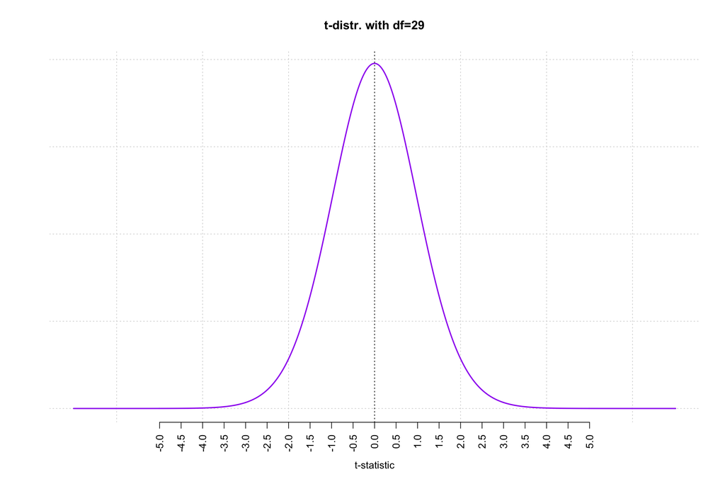

## Critical regions

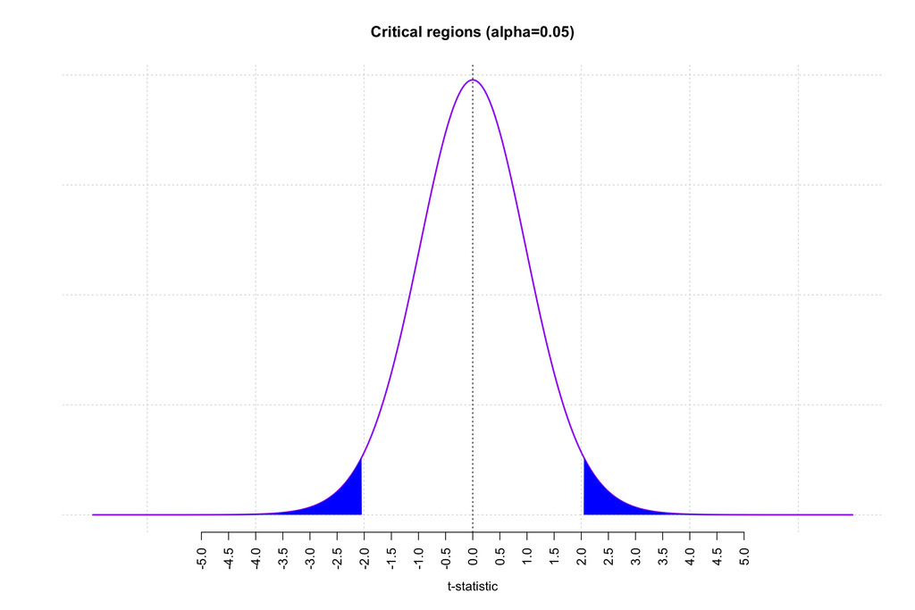

## Flipping the logic

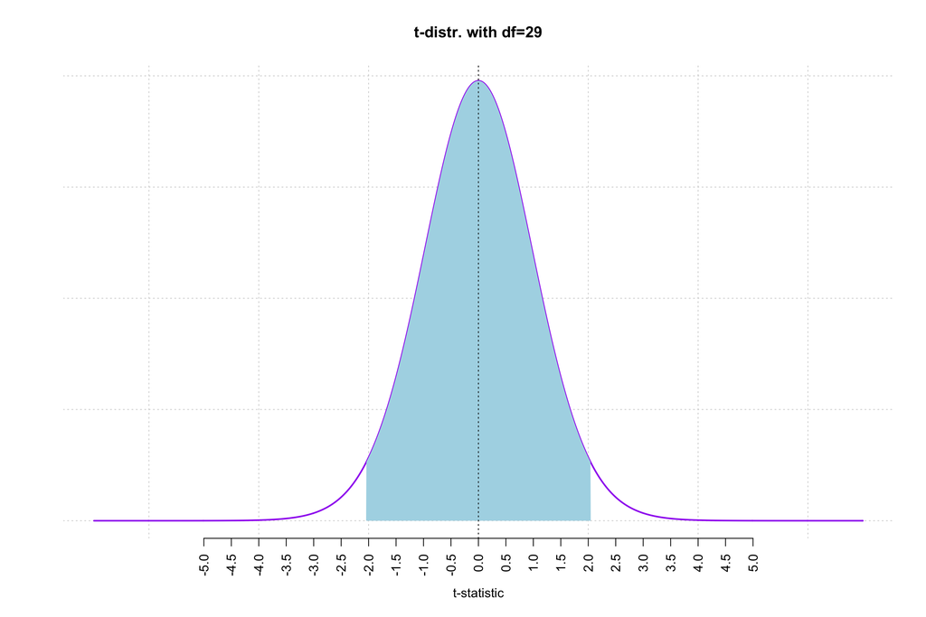

## Defining t for the CI

So we determine the level of confidence and find the respective t-value.

- Note: we need the two-sided value here because we are talking about an interval
- e.g. for 95% confidence intervals, we need the t-value that has a probability of 0.05 in both tails combined

For $t(29)$, the critical t-value is $\pm 2.045$

## Obtaining the 95% CI

Scenario: $M=5.46$, $SD=1.34$ for $n=100$

$\mu = M \pm t*s_M$

Critical t-value for two-sided $\alpha$ is for $df=99$ is 2.00

So: $\mu = 5.46 \pm 2.00*(\frac{s}{\sqrt{n}}) = 5.46 \pm 2.00*0.13 = 5.46 \pm 0.26$

The 95% confidence interval of the population mean $\mu$ is thus [5.20; 5.72].

## Interpretation

*The 95% confidence interval of the population mean $\mu$ is thus [5.20; 5.72].*

If we were to sample repeatedly with $n=100$ from that population and each time construct a 95% CI, then 95% of these intervals would contain the true value of $\mu$.

## CIs for other t-tests

*Independent t-test*

$t = \frac{(M_1-M_2)-(\mu_1-\mu_2)}{s_{(M_1-M_2)}} \leftrightarrow (\mu_1-\mu_2) = (M_1-M_2) \pm t*s_{(M_1-M_2)}$

Same logic!

## Calculating the CI

Scenario: poker players who mediated before they played ($M=4500$, $SD=780$) vs players who did not meditate ($M=3500$, $SD=580$) with $n_1 = n_2 = 25$

- Critical t for **99%** confidence for df=48? –> 2.704
- We know $s_{(M_1-M_2)}$ from above: 194.40

$(\mu_1-\mu_2) =(M_1-M_2) \pm t*s_{(M_1-M_2)} = ...$

$... = 4500-3500 \pm 2.704*194.40 = 1000 \pm 525.66$

The 99% CI of the true population mean difference is [474.34; 1525.66].

## CIs for the dependent t-test

From $t$ to $\mu$:

$t=\frac{(M_D-\mu_D)}{s_{M_{D}}} \leftrightarrow \mu_D = M_D \pm t*s_{M_{D}}$

## Calculating the 95% CI

Scenario: typing speed change after participants did it again, $M_D=16.80$, $s_{D}=22.33$ with $n=80$

- we know that $df=n-1=80-1=79$
- and: $s_{M_{D}} = 2.50$

Critical t-values for a 95% CI with $df=79$ –> $\pm 2.00$

## Obtaining the interval

$\mu_D = M_D \pm t*s_{M_{D}} = 16.80 \pm 2.00*2.50 = 16.80 \pm 5.00$

The 95% confidence interval of the population delta score is [11.80; 21.80].

## Factors that matter

CIs are influenced by two important factors:

- the confidence we want, and
- the sample size that was used

## Factors that matter

- the confidence level:
  - increasing the confidence makes the interval wider
  - i.e. we have a wider range of values
- 95% CI: [11.80; 21.80]
- 99% CI: [10.15; 23.45]

## The role of sample size

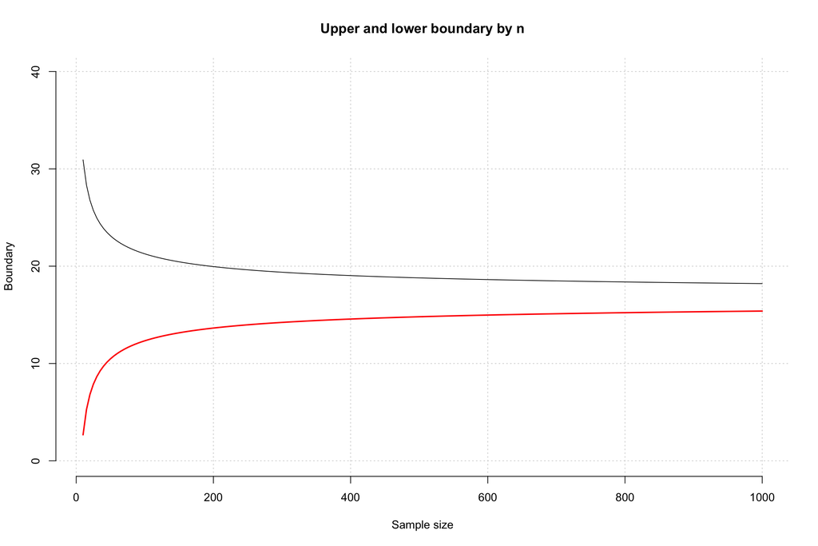

## In the live session

- effect sizes for all t-tests
- confidence intervals step-by-step

## Recap

- effect sizes allow us to understand the absolute magnitude of an effect
- effect sizes *correct for* sample size effects on the test statistics
- confidence intervals express the uncertainty about the population parameter
- they make probabilistic statements about a range of values around the true population value

## Next week

Statistical power